## Question 2: Laplace distribution

The double exponential (Laplace) distribution is given by formula:
$$DE(\mu, \lambda) =
\frac{\lambda}{2}exp({-\lambda|x-\mu|})$$
### a) Write a code generating double exponential distribution DE(0, 1) from Unif(0,1) by using the inverse CDF method. Explain how you obtained that code step by step. Generate 10000 random numbers from this distribution, plot the histogram and comment whether the result looks reasonable.

The cumulative distribution function of the Laplace distribution is given by:
$$F(x)= \int_{-\infty}^t f(t)dt
=\left\{ \begin{array}{rcl}
\frac{1}2 exp(\lambda(x-\mu) )&
\mbox{for} & x<\mu
\\1 - \frac{1}2 exp(-\lambda(x-\mu))
& \mbox{for} & x \geqslant \mu
\end{array}\right.$$

Which can be simplified to the following:
$$\frac{1}2 + \frac{1}2 sign(x-\mu)(1 -
exp(-\lambda|x-\mu|)$$
where sign(x) is the sign function, which is defined as:
$$sign(x) =
\left\{\begin{array}{rcl}
1 & \mbox{for} & x>0
\\0 & \mbox{for} & x = 0
\\-1 & \mbox{for} & x<0
\end{array}\right.$$
The inverse of the cumulative distribution function is given by:
$$F^{-1}(x) = \mu - \frac{1}\lambda sign(x-0.5)ln(1-2|x-0.5|)$$
(Source : https://en.wikipedia.org/wiki/Laplace_distribution)

This function can be used to generate random numbers from the Laplace distribution. The following code generates 10000 random numbers from the Laplace distribution and plots the histogram:

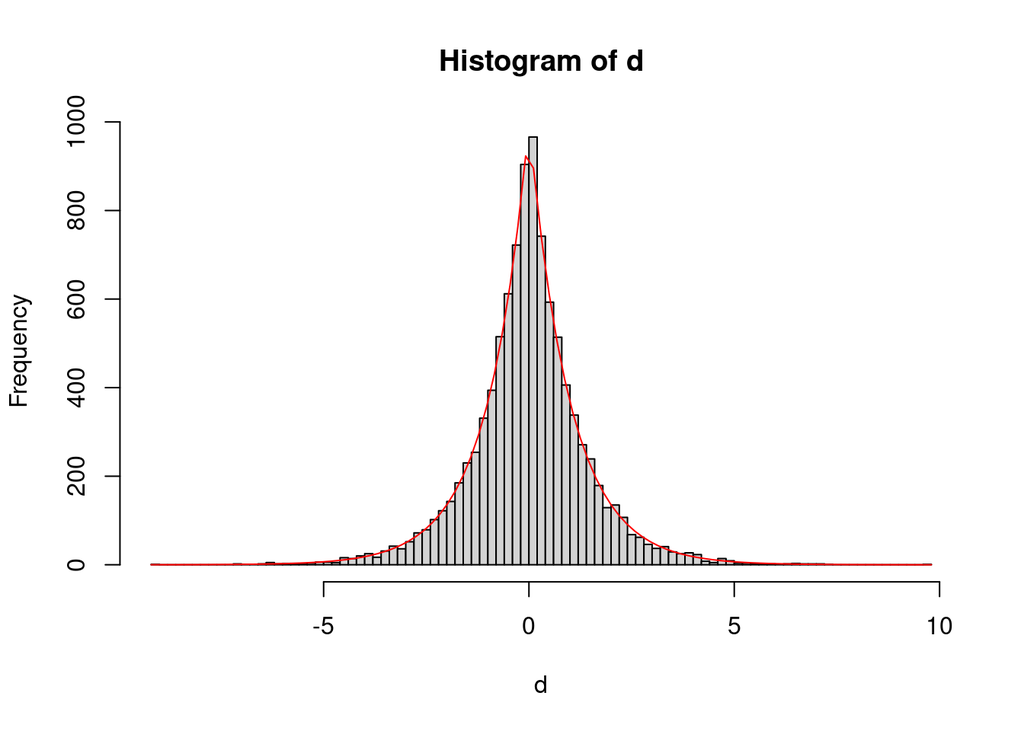

```r
de <- function(x, mu, lambda){
  return(lambda/2 * exp(-lambda * abs(x-mu)))
}
#Inverse CDF method
#Generate 10000 random numbers from Unif(0,1)
set.seed(12345)
u <- runif(10000)
#Generate 10000 random numbers from DE(0,1) using the inverse CDF method
F_inv <- function(p, mu, lambda){
  return(mu - (1/lambda) * sign(p-0.5)*log(1-2*abs(p-0.5)))
}
d <- F_inv(u, 0, 1)
hist(d, breaks = 100)
curve(de(x, 0, 1)*2000, add = TRUE, col = "red")
```

### b)

Use rejection sampling with DE(0, 1) as envelope to generate N(0, 1) variables. Explain step by step how this was done. How did you choose constant a in this method? Generate 2000 random numbers N (0, 1) using your code and plot the histogram. Compute the average rejection rate R in the rejection sampling procedure. What is the expected rejection rate ER and how close is it to R?

The rejection sampling method is based on the following theorem: Let $f$ be a probability density function and $g$ be a probability density function such that $f(x) \leqslant ag(x)$ for all $x$ and some constant $a$. Then the following algorithm generates a random variable $X$ with density $f$: 1. Generate $Y$ from $g$ 2. Generate $U$ from $U(0,1)$ 3. If $U \leqslant \frac{f(Y)}{ag(Y)}$ then set $X=Y$ otherwise go to step 1.

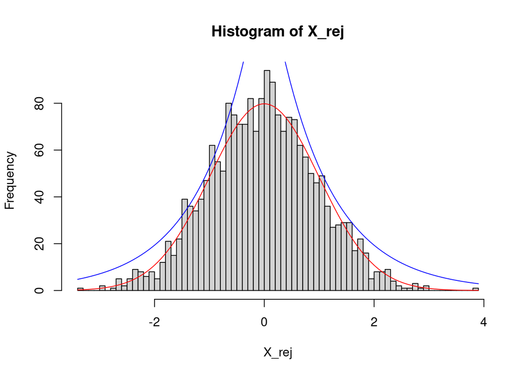

```r
#Rejection sampling method
#Determining proper value of a for the enveloppe
a <- 0.7
#plot(x, f(x), col = "red", type = "l")
#lines(x, g(x, 0, 1)/a, col = "blue")

#Generate 2000 random numbers from DE(0,1)
set.seed(12345)
u <- runif(2000)
Y <- F_inv(u, 0, 1)*a

f <- function(x){
  return(dnorm(x, 0, 1))
}
g <- function(x, mu, lambda){
  return(de(x, mu, lambda))
}

#After trial and error, a = 0.7 seems to be the best value for a

#Generate 2000 random numbers from N(0,1) using the rejection sampling method
X_rej <- c()
samples <- 0
rejection_rate <- 0
while(length(X_rej) < 2000){
  samples <- samples + 1
  Y <- F_inv(runif(1), 0, 1)
  U <- runif(1, 0,1)
  if(U <= f(Y)/(g(Y, 0, 1)/a)){
    X_rej <- c(X_rej, Y)
  }else{
    rejection_rate <- rejection_rate + 1
  }
}
rejection_rate <- rejection_rate/samples

hist(X_rej, breaks = 100)
curve(dnorm(x, mean = 0, sd = 1)*200, add = TRUE, col = "red")
curve(de(x, 0, 1)*200/a, add = TRUE, col = "blue")
```

The rejection rate is 0.2910315.

Generate 2000 numbers from N (0, 1) using standard rnorm() procedure, plot the histogram and compare the obtained two histograms.

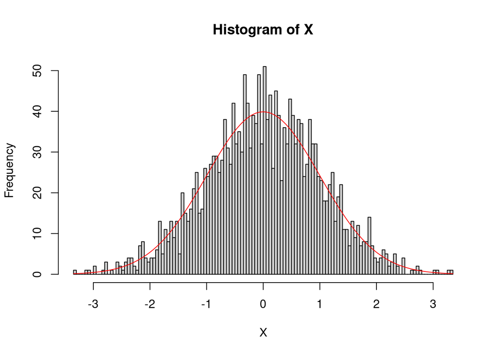

```r
#Generate 2000 random numbers from N(0,1) using rnorm()
set.seed(12345)
X <- rnorm(2000, mean = 0, sd = 1)
hist(X, breaks = 100)
curve(dnorm(x, mean = 0, sd = 1)*100, add = TRUE, col = "red")
```

Comparaison:

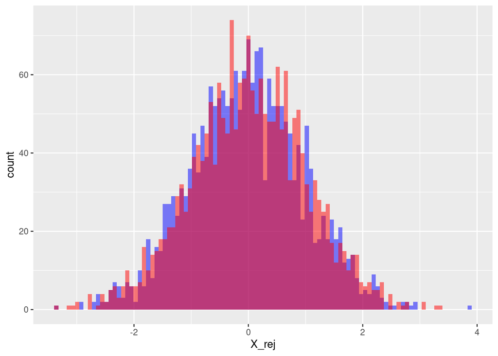

```r
library(ggplot2)
df1 <- data.frame(X_rej)
df2 <- data.frame(X)
#Comparaison of the histograms
ggplot(df1, aes(x = X_rej)) + geom_histogram(bins= 100,fill = "blue", alpha = 0.5) + geom_histogram(data = df2, aes(x = X), bins = 100, fill = "red", alpha = 0.5)
```

The two histograms are very similar.